# Immigration and Wages in the USA: A State-Level Exploratory Analysis.

Jennifer

2026-04-06

## Topic, Motivation, and Data

## Research Topic

This topic investigates the relationship between immigration and wages in the United States, examined at the state level using multiple decades of data (1970, 1980, 1990, 2000, 2010, 2020). The central question is whether immigration affects wage levels — specifically, whether an increase in the immigrant workforce leads to higher or lower wages for workers.

#Research questions (Descriptive)How do average wages differ between immigrants and native born workers across states in the United States? How does the immigrant share vary across states, and how is it associated with differences in average wages across states?To what extent are differences in wages across states driven by differences in worker characteristics, such as education, rather than immigration itself? Answered w/ fig 2 (Causal) Does a higher immigrant share in a state cause wages to increase or decrease for workers in that state?

## Motivation

Immigration has been one of the most debated economic and political issues in the United States. Labor economists have long studied whether immigration complements or competes with native workers (Borjas 1987; Card 1990; Peri 2012). The empirical evidence is complicated because immigrants are not randomly distributed across locations — they tend to move to high-wage, high-opportunity areas, creating a selection problem. The inclusion of multiple decades of data allows for the examination of changes in immigration patterns over time, including the role of major policy shifts.

## Data

The data come from the Current Population Survey (CPS) ASEC supplement, accessed through IPUMS CPS (Flood et al. 2023). The CPS is the primary source of labor force and earnings data in the United States and is conducted monthly by the Census Bureau and the Bureau of Labor Statistics. The ASEC supplement (Annual Social and Economic Supplement), administered each March, includes detailed earnings information not available in the monthly survey.

The dataset covers the years 1970, 1980, 1990, 2000, 2010, and 2020. However, the key variables for this analysis — weekly earnings (EARNWEEK) and immigration status (NATIVITY) — are only simultaneously available in 2000, 2010, and 2020, which form the core analysis sample. The earlier years are retained to examine immigration-related policy shocks and broader historical trends. The raw extract contains 986,061 observations across 21 variables.

Key variables used in this analysis: EARNWEEK: Usual weekly earnings on the primary job NATIVITY: Immigration status (native vs. foreign-born) STATEFIP: State FIPS code ASECWT: Person-level survey weight AGE SEX EDUC: Educational attainment EMPSTAT: Employment status

## Data Cleaning

Variable selection and renaming. I selected 13 variables relevant to the analysis and renamed them foe easy identification. All other columns were dropped.

Primary key verification. Each row is uniquely identified by (year, serial, pernum). I confirmed zero duplicate combinations, establishing the row as a valid person-year record.

Recoding categorical variables. The binary immigrant indicator was constructed from IPUMS’s NATIVITY code: values 1–3 (native-born in the US, abroad to American parents, or in a US territory) were coded 0; values 4–5 (foreign-born citizens and non-citizens) were coded 1; and code 0 (not collected, appearing only in pre-2000 waves) was set to NA. This native vs. foreign-born distinction follows the standard used in the immigration economics literature. Employment status was recoded to a binary (employed = EMPSTAT codes 10 or 12). Education was collapsed from fine-grained IPUMS codes into four ordered tiers: less than high school, high school diploma, some college, and bachelor’s degree or more.

State crosswalk. A manual crosswalk was joined to the FIPS codes to add state abbreviations and full names used in figure labels.

Missing Data and Sentinel Values

The CPS data required careful treatment of IPUMS-specific sentinel values — special numeric codes used to indicate “not applicable” rather than true missing data.

Weekly earnings (EARNWEEK). The value 9999.99 serves as a dual sentinel in this extract: it indicates either that the respondent was not part of the ASEC supplement (and was never asked the earnings question) or that their earnings were top-coded at the survey’s maximum. I converted all 9999.99 values to NA. Approximately 94% of all rows are missing earn_week — this is expected and not a data quality problem; it simply reflects the survey design and the focus on employed ASEC respondents.

Usual hours worked (UHRSWORKT). The values 999 (“not applicable”) and 997 (“hours vary”) were both converted to NA. Because weekly earnings are used rather than hourly wages as the primary outcome, the loss of hours information does not compromise the core analysis.

Transformations and Extreme Values

## Exploratory Analysis

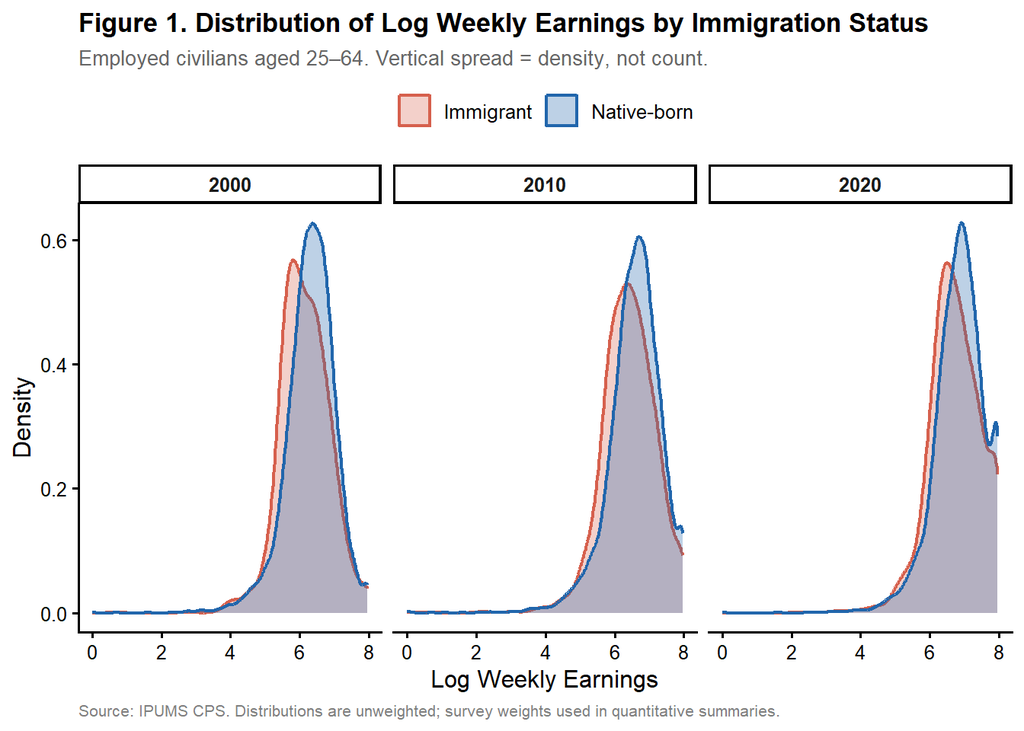

Figure 1 shows overlapping density estimates of log weekly earnings for immigrant and native born workers in each of the three survey years. The immigrant distribution sits to the left of the native born distribution across all years, indicating that immigrants on average earn less than comparable native born workers. However, the distributions overlap substantially, and there are many high earning immigrants and many lower earning native born workers. The gap does not appear to have widened dramatically from 2000 to 2020, though a more precise assessment will be provided in the regression analysis in Stage 3.

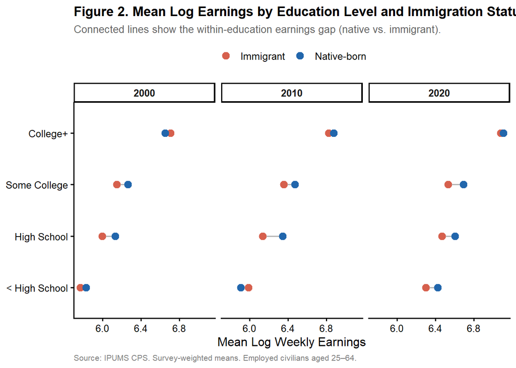

## Is there a visible association between immigrant workforce concentration and wage levels across states

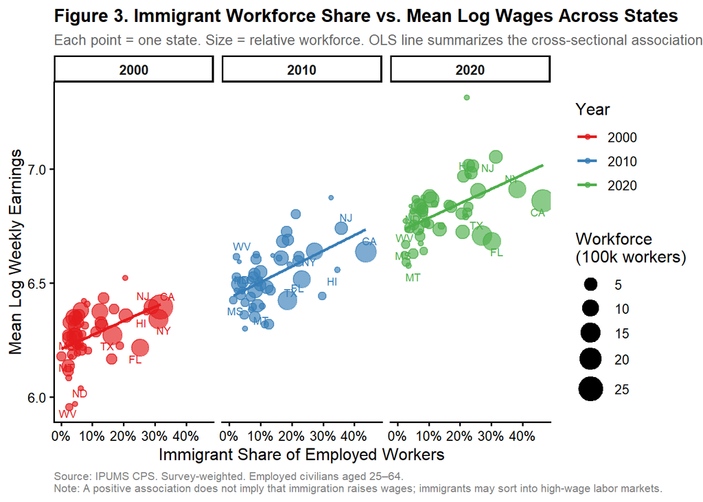

## changed in immigrant workforce share over the study period in each state

[figure not shown]